# Uden_filtering

# Dispersion

However, PERMANOVA results should always be interpreted carefully because significant results can sometimes be driven not only by differences in group location, but also by differences in within-group dispersion.

Checking homogeneity of dispersion

To evaluate this, we can use betadisper() from the vegan package.

```r
dispersion_bray <- betadisper(
  bray_dist,
  sample_df$Project.ID
)

anova(dispersion_bray)
```

```
## Analysis of Variance Table
##
## Response: Distances
##            Df Sum Sq  Mean Sq F value  Pr(>F)
## Groups      2 0.1665 0.083261  3.7639 0.02396 *
## Residuals 429 9.4898 0.022121
## ---
## Signif. codes:  0 '***' 0.001 '**' 0.01 '*' 0.05 '.' 0.1 ' ' 1
```

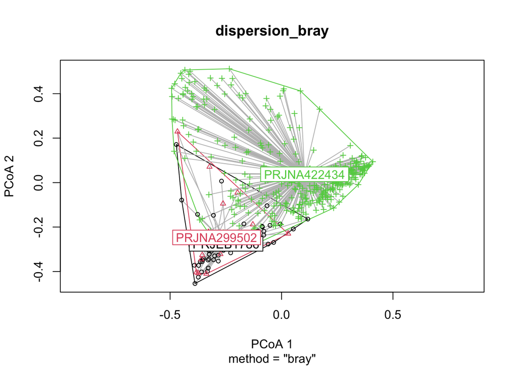

```r
plot(dispersion_bray)
```

If dispersion differs strongly between groups, then a significant PERMANOVA result should be interpreted with caution.

# Resultat

Det betyder:

mindst ét Project.ID har signifikant forskellig dispersion.

### Alpha diversitet

The code below calculates both Shannon diversity, converts the sample names into an explicit column (sample_id), extracts the sample metadata, and finally merges everything into a single table.

# pre-processering af data

```r
# Calculate Shannon diversity
shannon <- estimate_richness(
  ps_genus,
  measures = "Shannon"
) %>%
  rownames_to_column("sample_id")
# Extract sample metadata
sample_df <- sample_data(ps_genus) %>%
  data.frame() %>%
  rownames_to_column("sample_id")

# Combine diversity estimates and metadata
alpha_diversity <- inner_join(
  shannon,
  sample_df,
  by = "sample_id"
)

head(alpha_diversity)
```

```
##   sample_id  Shannon    Run.ID Project.ID Experiment.type Nr..reads.sequenced
## 1 ERR260139 1.737425 ERR260139  PRJEB1786    Metagenomics            10082557
## 2 ERR260140 1.824070 ERR260140  PRJEB1786    Metagenomics             9583450
## 3 ERR260144 1.891846 ERR260144  PRJEB1786    Metagenomics            12296547
## 4 ERR260149 1.917806 ERR260149  PRJEB1786    Metagenomics            15256432
## 5 ERR260151 1.919926 ERR260151  PRJEB1786    Metagenomics            13021937
## 6 ERR260152 1.952531 ERR260152  PRJEB1786    Metagenomics             8978017
##   Country    Sex Host.age BMI Recent.antibiotics.use Disease.MESH.ID
## 1  Sweden Female    70.25  NA                                D003924
## 2  Sweden Female    70.15  NA                                D003924
## 3  Sweden Female    69.58  NA                                D003924
## 4  Sweden Female    70.14  NA                                D003924
## 5  Sweden Female    71.57  NA                                D003924
## 6  Sweden Female    71.24  NA                                D003924
##   Disease.name QC.status
## 1            1         1
## 2            1         1
## 3            1         1
## 4            1         1
## 5            1         1
## 6            1         1
```

# Selve test

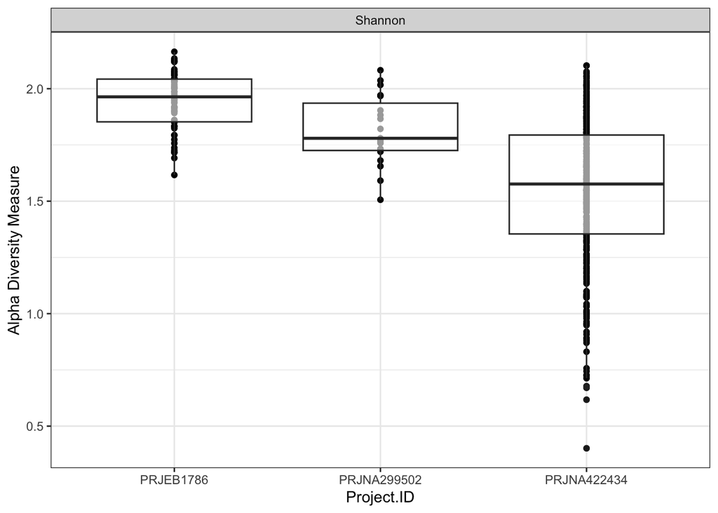

```r
# Group samples by disease
plot_richness(
  ps_genus,
  measures = c("Shannon"),
  x = "Project.ID"
) +
  geom_boxplot(alpha = 0.6) +
  theme_bw()
```

```r
# Stat  - # er alpha diversitet forskellig mellem midst to grupper?
kruskal_country <- kruskal.test(
  Shannon ~ Project.ID,
  data = alpha_diversity
)
kruskal_country
```

```
##
##  Kruskal-Wallis rank sum test
##
## data:  Shannon by Project.ID
## Kruskal-Wallis chi-squared = 95.377, df = 2, p-value < 2.2e-16
```

```r
# pair
pw_shannon <- pairwise.wilcox.test(
  x = alpha_diversity$Shannon,
  g = alpha_diversity$Project.ID,
  p.adjust.method = "BH"
)
pw_shannon
```

```
##
##  Pairwise comparisons using Wilcoxon rank sum test with continuity correction
##
## data:  alpha_diversity$Shannon and alpha_diversity$Project.ID
##
##             PRJEB1786 PRJNA299502
## PRJNA299502 0.00260   -
## PRJNA422434 < 2e-16   0.00012
##
## P value adjustment method: BH
```

# Anbefalinger fra AI - NB undersøg senere

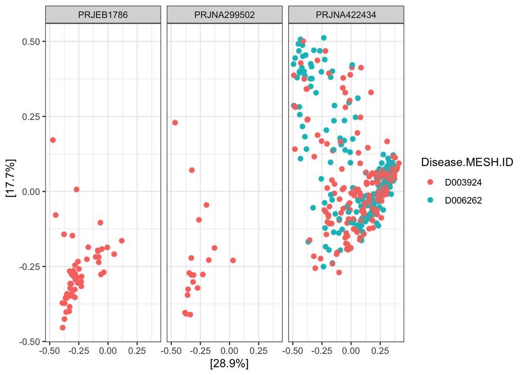

```r
plot_ordination(ps_rel, ord_bray,
                 color = "Disease.MESH.ID") +
  geom_point(size = 2, alpha = 0.7) +
  facet_wrap(~Project.ID) +
  theme_bw()
```

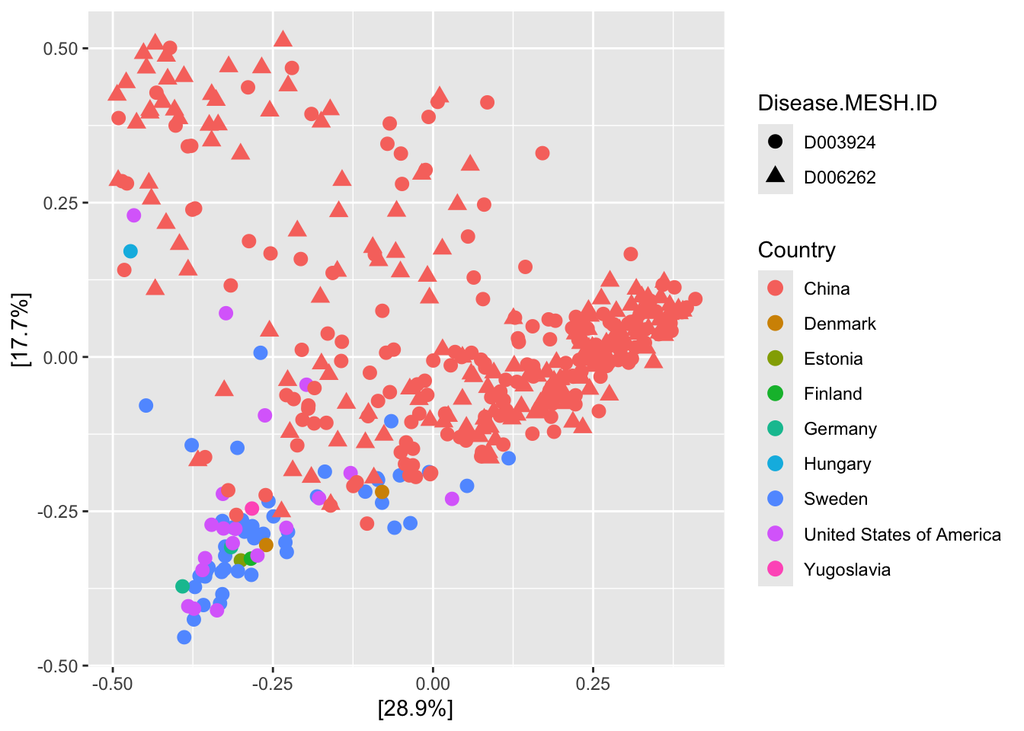

```r
plot_ordination(ps_rel, ord_bray,
                 color = "Country",
                 shape = "Disease.MESH.ID") +
  geom_point(size = 3)
```

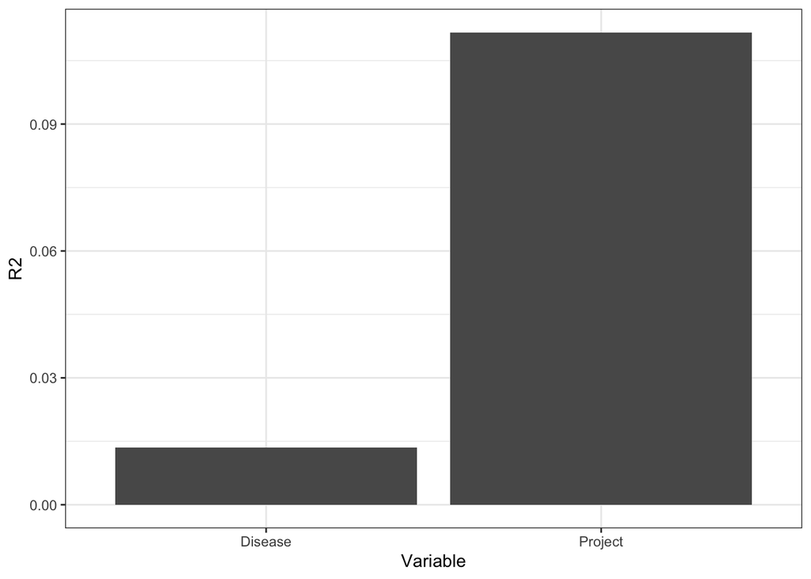

```r
adonis_res <- data.frame(
  Variable = c("Project", "Disease"),
  R2 = c(0.11167, 0.01358)
)

ggplot(adonis_res,
       aes(Variable, R2)) +
  geom_col() +
  theme_bw()
```